# Word Prediction Milestone Report

December 24, 2015

This is a milestone report for the word prediction capstone project. In this project we will be applying data science in the area of natural language processing. The objective of the project is to build an app that can predict the “next” word given a series of words. The data to build the app is available from a corpus called HC Corpora (www.corpora.heliohost.org). This milestone assignment is to do explorations of the source data, that can later be used to build a model for the word prediction.

## Transformations

The following transformations were done on the data to keep the exploration (and modeling) simple.

- All cases have been converted to lower case.
- All numerals have been removed.
- All punctuation have been removed.
- All white space has been stripped off.

## N-Gram Counts

The transformed data has been processed to identify all the unique words, bigrams and trigrams.

- There are 33204 unique words.
- There are 205443 unique bigrams.
- There are 338365 unique trigrams.

Probably we may need to look at more ngrams to build the model. For now we are stopping at trigrams.

## Popular Terms

Let’s take a look at the most popular terms in the source data. The 20 most popular terms are shown in the histograms below.

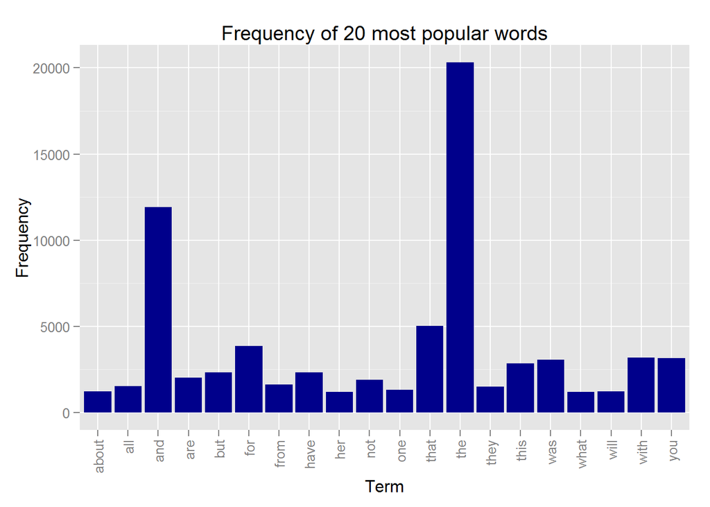

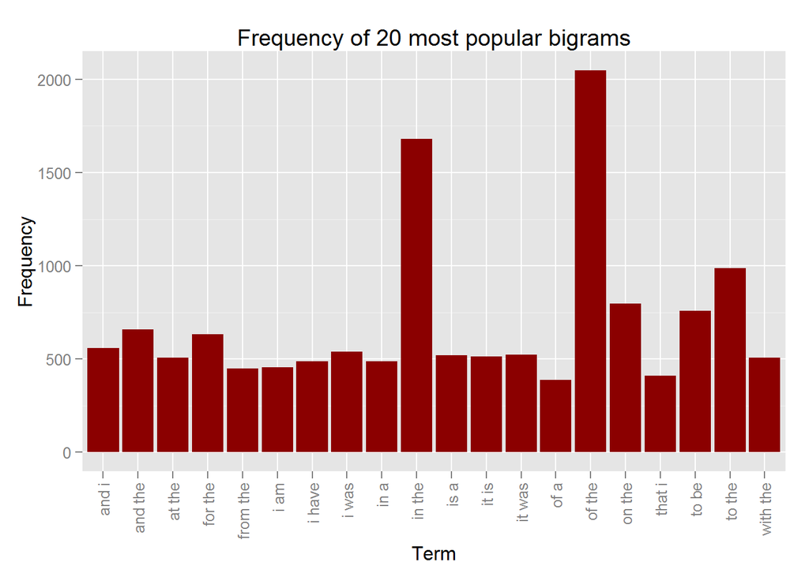

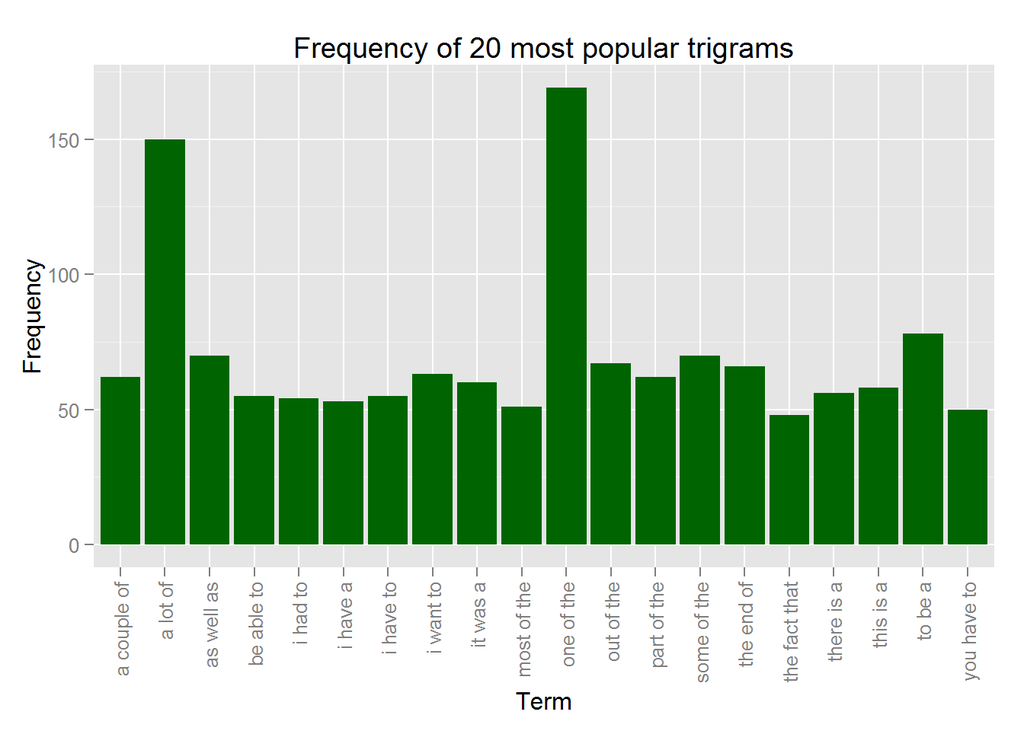

## Frequency of Occurence

The frequency of occurence of N-grams can be classified into different levels. As part of this exploratory analysis five such levels have been considered.

- A: Just 1 occurence
- B: Between 1 and 10 occurences
- C: Between 10 and 50 occurences
- D: Between 50 and 100 occurences
- E: More than 100 occurences

Frequency of occurence of unique words is as follows:

```
##
##             A: Just 1   B: Between 1 and 10  C: Between 10 and 50
##                 18220                 11665                  2540
## D: Between 50 and 100      E: More than 100
##                   409                   370
```

Frequency of occurence of bigrams (2 word combinations) is as follows:

```
##
##             A: Just 1   B: Between 1 and 10  C: Between 10 and 50
##                166958                 35148                  2882
## D: Between 50 and 100      E: More than 100
##                   289                   166
```

Frequency of occurence of trigrams (3 word combinations) is as follows:

```
##
##             A: Just 1   B: Between 1 and 10  C: Between 10 and 50
##                316919                 20877                   551
## D: Between 50 and 100      E: More than 100
##                    16                     2
```

## Observations and Questions

We can see that the number of terms with a high level of frequency is comparatively less. So it may make sense to prune out the sparse terms before building the model.

Most of the popular terms are based on stop words. Would it make sense to have a separate strategy/model to handle stop words?